# IODS course project

Juho Koistinen

# Introduction to Open Data Science - Course Project

# About the project

This is the course diary for the course Introduction to Data Science, organized by University of Helsinki in Fall 2022. Here I will update my progress on the course, as well as the actual course work during the next six weeks. I heard about the course through a mailing list and it caught my attention as it is could support my research. I do empirical research in macroeconomics and therefore I deal with large data sets on a daily basis. This is why it is useful for me to learn new routines and ideas on data management.

# Chapter 2

…

# Chapter 3

```r
library(tidyverse)
alc <- read_csv("data/alc.csv")
```

## Q2

The data set consists of 35 variables of 370 students in secondary education of two Portugese schools. This survey data were gathered in 2014. The data are discrete and consist of 14 binary and 21 non-binary covariates describing student backgrounds. Examples of the former are access to internet or to family educational support and, of the latter, time used for travelling to school or for weekly studies. The number of unique values per variable as well as the variable names are given in the graph below. We see that there is considerable variation in the non-binary variables, with the minimum and maximum number of unique values in this group being 3 and 26, respectively.

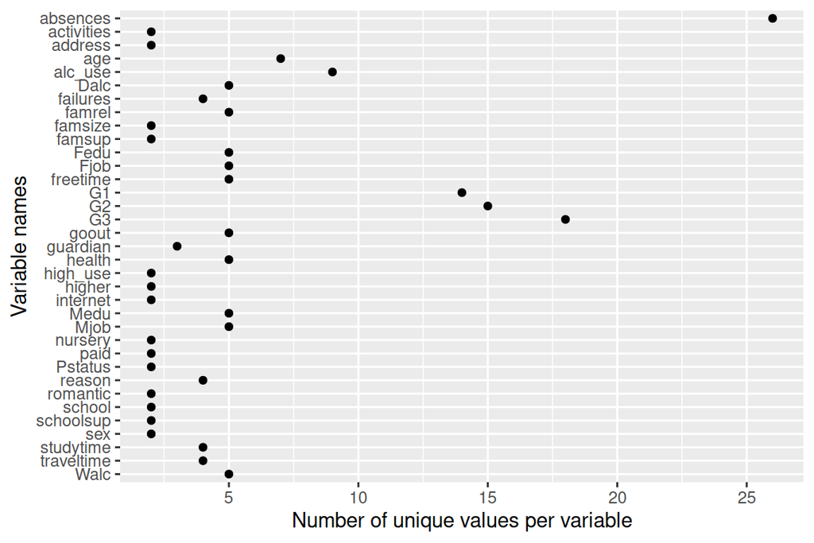

```r
tibble(n_uniq = apply(alc, 2, function(x) length(unique(x))),
       var_name = names(n_uniq)) %>%
  ggplot(aes(x = n_uniq, y=var_name)) +
  geom_point() +
  scale_y_discrete(limits=rev) +
  scale_x_continuous(breaks=seq(5,25, by=5)) +
  xlab("Number of unique values per variable") +
  ylab("Variable names")
```

## Q3

I choose two variables from both groups of binary and non-binary variables. Chosen variables from the former group are parents’ cohabitation status and access to extra educational support, while, of the latter group, I choose the number of past failures and home to school travel time. I expect that the parents’ living apart and no access to extra educational support are positively correlated with higher alcohol use. Finally, I expect that the number of past failures and home to school travel time are positively correlated with the alcohol use.

## Q4

To explore the relationship between alcohol use and the chosen covariates, I use two different graphical tools. In the first one, I set the binary variables in the x-axis and the shares of each group denoting the alcohol use on a scale 1 to 5 stacked in the y-axis. This facilitates an easy comparison between the groups even though the numbers of cases between the binary variables vary. We would expect that the bars on the left have larger share of small values than those in the right.

We see that the postulated hypothesis on the relationship between the binary variables and alcohol use might not be as strong as expected. In the both cases, the proportion of the respondents having alcohol use below level 2 is almost the same. Moreover, the proportion of respondents having the highest level of alcohol use (5) is considerably higher with respondents with access to educational support, which is surprising. In summary, the relationship between these binary variables and alcohol use is very weak.

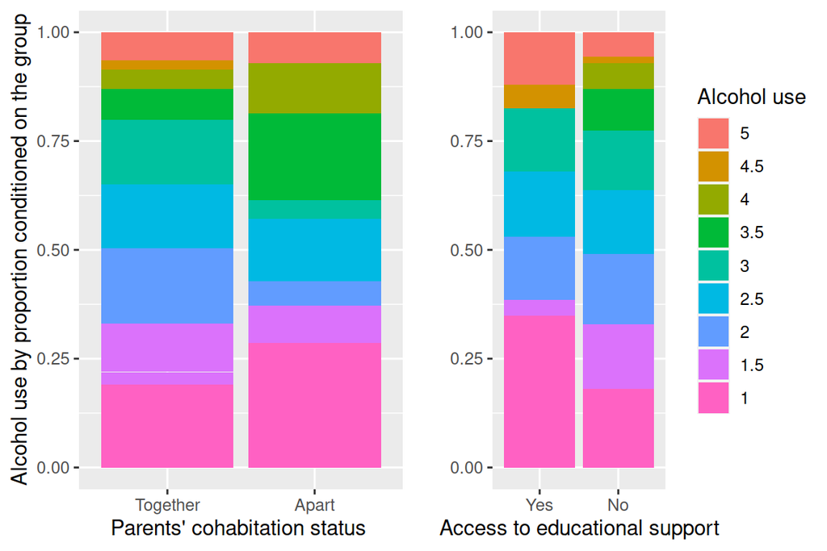

```r
alc <- alc %>%
  mutate(Pstatus = map_chr(.x = Pstatus, ~ifelse(.x=="A", "Apart", "Together")))
alc %>%
  ggplot(aes(fill = factor(alc_use, levels = as.character(seq(5, 1, by = -0.5))),
             y = alc_use,
             x = factor(Pstatus, levels = c("Together", "Apart")))) +
  geom_bar(position="fill", stat="identity") +
  ylab("Alcohol use by proportion conditioned on the group") +
  xlab("Parents' cohabitation status ") +
  scale_fill_discrete(guide="none") -> p1

alc <- alc %>%
  mutate(schoolsup = map_chr(.x = schoolsup, ~ifelse(.x=="yes", "Yes", "No")))
alc %>%
  ggplot(aes(fill = factor(alc_use, levels = as.character(seq(5, 1, by = -0.5))),
             y = alc_use,
             x = factor(schoolsup, levels = c("Yes", "No")))) +
  geom_bar(position="fill", stat="identity") +
  ylab("") +
  xlab("Access to educational support") +
  scale_fill_discrete("Alcohol use") -> p2
gridExtra::marrangeGrob(list(p1,p2), nrow = 1, ncol = 2, top = NULL)
```

Second, I use the box plots to describe the relationship between alcohol use (y-axis) and the non-binary covariates (x-axis), which both are given conveniently four distinct values. Here we see a considerably stronger relationship between alcohol use and the chosen covariates. The median values (denoted by the vertical line in the bar) increase with the travel time to school and past failures. Also, we see that the 25th percentile of the groups, which have the highest values for both travel time to school and past failures, are above the 75th percentiles of the groups with the smallest values in these categories. These indicate stronger relationship between alcohol use and the chosen covariates.

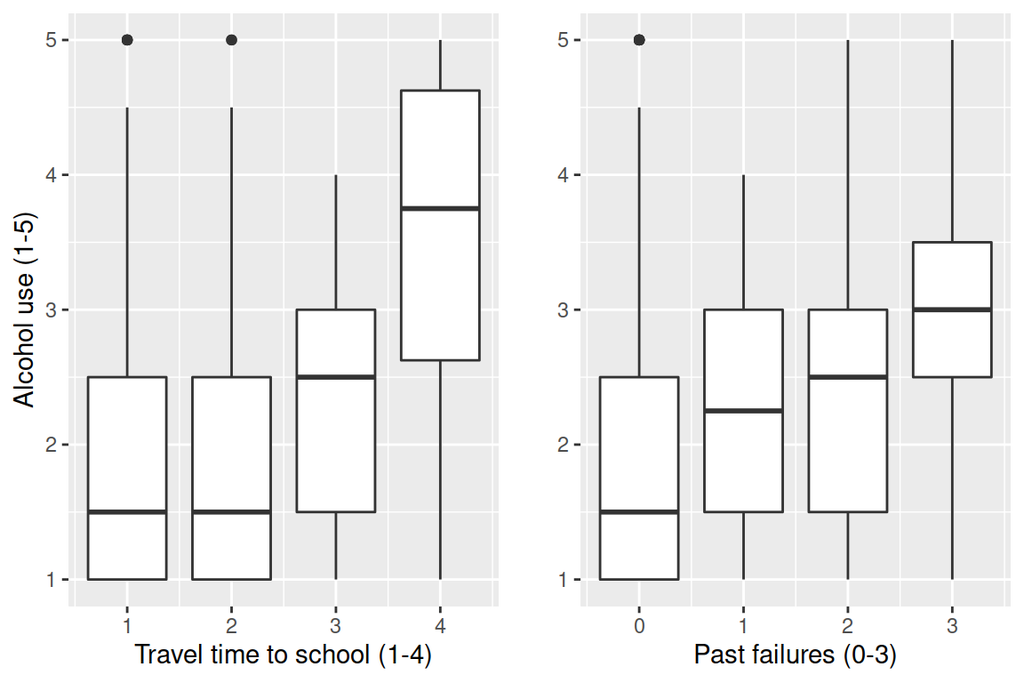

```r
alc %>% ggplot(aes(x = traveltime, y=alc_use, group=traveltime)) +
  geom_boxplot() +
  ylab("Alcohol use (1-5)") +
  xlab("Travel time to school (1-4)") -> p1
alc %>%
  ggplot(aes(x = failures, y=alc_use, group = failures)) +
  geom_boxplot() +
  ylab("") +
  xlab("Past failures (0-3)") -> p2
gridExtra::marrangeGrob(list(p1,p2), nrow = 1, ncol = 2, top = NULL)
```

## Q5

The logistic regression results are given below. Two remarks are in order. First, the results confirm the earlier intuition that there is no strong linear relationship between the binary variables and alcohol use. The coefficients of the regression are not different from zero at the conventional significance levels. Second, the graphical intution of the non-binary variables is confirmed and the alcohol use appears to be linearly dependent on the non-binary covariates. Both of the coefficients pertaining to the non-binary variables are different from zero at the 5 percent significance level, as shown in the column for p-values.

```r
glm_obj <- glm(high_use ~ Pstatus + schoolsup + traveltime + failures, data = alc, family = "binomial")
glm_obj %>% broom::tidy() %>% mutate_if(is.numeric, round, 4) %>% DT::datatable()
```

|  | term | estimate | std.error | statistic | p.value |
| --- | --- | --- | --- | --- | --- |
| 1 | (Intercept) | -1.3281 | 0.4257 | -3.1199 | 0.0018 |
| 2 | PstatusTogether | -0.1652 | 0.3805 | -0.4342 | 0.6642 |
| 3 | schoolsupYes | -0.3289 | 0.3626 | -0.9071 | 0.3644 |
| 4 | traveltime | 0.3615 | 0.1607 | 2.2504 | 0.0244 |
| 5 | failures | 0.6341 | 0.1996 | 3.1769 | 0.0015 |

Next, below are the odds ratios calculated from the previous regression model. The odds ratios of the non-binary variables are above one and do not contain one in their 95 percent confidence intervals, and this confirms that the association between alcohol use and the non-binary variables. In summary, there is higher relative risk in using high amounts of alcohol with longer distance to school and past fails compared to those with shorter distance to school and fewer past failures, keeping the other variables fixed.

```r
OR <- coef(glm_obj) %>% exp
CI <- confint(glm_obj) %>% exp()
cbind(OR, CI) %>% round(4) %>% DT::datatable()
```

|  | OR | 2.5 % | 97.5 % |
| --- | --- | --- | --- |
| (Intercept) | 0.265 | 0.1115 | 0.5982 |
| PstatusTogether | 0.8477 | 0.4098 | 1.8441 |
| schoolsupYes | 0.7197 | 0.3406 | 1.4269 |
| traveltime | 1.4355 | 1.0464 | 1.9702 |
| failures | 1.8853 | 1.2835 | 2.827 |

# Chapter 4

```r
library(MASS)
library(corrplot)
library(tidyverse)
library(ggplot2)
set.seed(123) # for training data sample
data(Boston)
lda.arrows <- function(x, myscale = 1, arrow_heads = 0.1, color = "red", tex = 0.75, choices = c(1,2)){
  heads <- coef(x)
  arrows(x0 = 0, y0 = 0,
         x1 = myscale * heads[,choices[1]],
         y1 = myscale * heads[,choices[2]], col=color, length = arrow_heads)
  text(myscale * heads[,choices], labels = row.names(heads),
       cex = tex, col=color, pos=3)
}
```

## Q2

The data set under analysis consists of 506 observations from 14 variables relating to housing in Boston. The data are numerical with with one dummy variable. The data are informative about the housing values in suburbs of Boston, and details many background factors useful for someone potentially wanting to buy a house from Boston. The number of unique values per variable are given in the figure below. We see that the number of unique values vary from 2 to 504 with the former denoting the dummy variable **chas**.

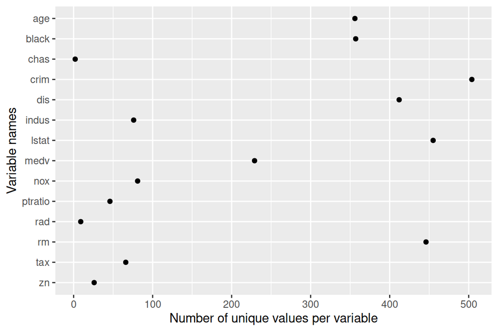

```r
tibble(n_uniq = apply(Boston, 2, function(x) length(unique(x))),
       var_name = names(n_uniq)) %>%
  ggplot(aes(x = n_uniq, y=var_name)) +
  geom_point() +
  scale_y_discrete(limits=rev) +
  #scale_x_continuous(breaks=seq(5,25, by=5)) +
  xlab("Number of unique values per variable") +
  ylab("Variable names")
```

## Q3

```r
smr_tbl <- apply(Boston, 2, summary)
cor_mt <- cor(Boston)
```

The summaries and associated box plots of the variables are given below. The data are strongly of different scale as exemplified by the range of the mean values 0.07–408.24 and median values 0–391.44. The variables **crim**, **zn**, and **black** are strongly skewed, former two to right, and the latter to left, as shown by the box plot and the comparison between the respective means and medians. Apart from these three variables, the rest appear to be centered around their means. The variable **dis** appears to exhibit strongest correlation with the other variables, with strong negative relationship between this and variables **indus**, **nox** and **age**.

```r
DT::datatable(apply(smr_tbl, 2, round, digits = 2))
```

|  | crim | zn | indus | chas | nox | rm | age | dis | rad | tax | ptratio | black | lstat | medv |
| --- | --- | --- | --- | --- | --- | --- | --- | --- | --- | --- | --- | --- | --- | --- |
| Min. | 0.01 | 0 | 0.46 | 0 | 0.38 | 3.56 | 2.9 | 1.13 | 1 | 187 | 12.6 | 0.32 | 1.73 | 5 |
| 1st Qu. | 0.08 | 0 | 5.19 | 0 | 0.45 | 5.89 | 45.02 | 2.1 | 4 | 279 | 17.4 | 375.38 | 6.95 | 17.02 |
| Median | 0.26 | 0 | 9.69 | 0 | 0.54 | 6.21 | 77.5 | 3.21 | 5 | 330 | 19.05 | 391.44 | 11.36 | 21.2 |
| Mean | 3.61 | 11.36 | 11.14 | 0.07 | 0.55 | 6.28 | 68.57 | 3.8 | 9.55 | 408.24 | 18.46 | 356.67 | 12.65 | 22.53 |
| 3rd Qu. | 3.68 | 12.5 | 18.1 | 0 | 0.62 | 6.62 | 94.07 | 5.19 | 24 | 666 | 20.2 | 396.22 | 16.96 | 25 |
| Max. | 88.98 | 100 | 27.74 | 1 | 0.87 | 8.78 | 100 | 12.13 | 24 | 711 | 22 | 396.9 | 37.97 | 50 |

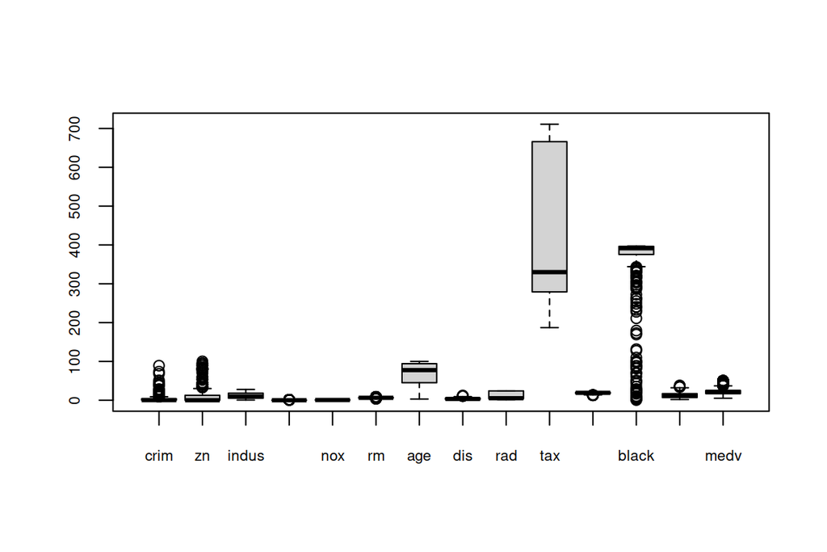

```r
boxplot(as.matrix(Boston), cex.axis=0.65)
```

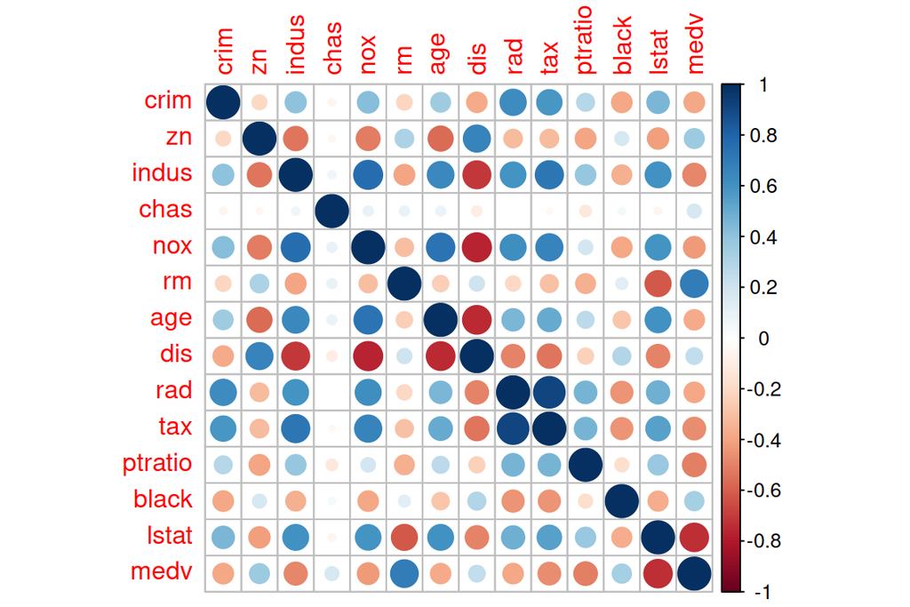

```r
corrplot(cor_mt, method="circle")
```

## Q4

```r
data_std <- as_tibble(Boston) %>%
  mutate(across(!chas, ~(.x-mean(.x))/sd(.x)))
smr_tbl <- apply(data_std, 2, summary)
cor_mt <- cor(data_std)
```

The standardised data (apart from dummy variable **chas**) are shown below. The standardisation does not remove any outliers but renders the variables to same scale. This helps detecting further properties of the data from with the boxplot, such as **rm** having fatter tails in comparison to other variables. For the same skewed variables as mentioned before, one could entertain a logarithmic transformation to remove the strongly skewed nature of certain variables.

```r
DT::datatable(apply(smr_tbl, 2, round, digits = 2))
```

|  | crim | zn | indus | chas | nox | rm | age | dis | rad | tax | ptratio | black | lstat | medv |
| --- | --- | --- | --- | --- | --- | --- | --- | --- | --- | --- | --- | --- | --- | --- |
| Min. | -0.42 | -0.49 | -1.56 | 0 | -1.46 | -3.88 | -2.33 | -1.27 | -0.98 | -1.31 | -2.7 | -3.9 | -1.53 | -1.91 |
| 1st Qu. | -0.41 | -0.49 | -0.87 | 0 | -0.91 | -0.57 | -0.84 | -0.8 | -0.64 | -0.77 | -0.49 | 0.2 | -0.8 | -0.6 |
| Median | -0.39 | -0.49 | -0.21 | 0 | -0.14 | -0.11 | 0.32 | -0.28 | -0.52 | -0.46 | 0.27 | 0.38 | -0.18 | -0.14 |
| Mean | 0 | 0 | 0 | 0.07 | 0 | 0 | 0 | 0 | 0 | 0 | 0 | 0 | 0 | 0 |
| 3rd Qu. | 0.01 | 0.05 | 1.01 | 0 | 0.6 | 0.48 | 0.91 | 0.66 | 1.66 | 1.53 | 0.81 | 0.43 | 0.6 | 0.27 |
| Max. | 9.92 | 3.8 | 2.42 | 1 | 2.73 | 3.55 | 1.12 | 3.96 | 1.66 | 1.8 | 1.64 | 0.44 | 3.55 | 2.99 |

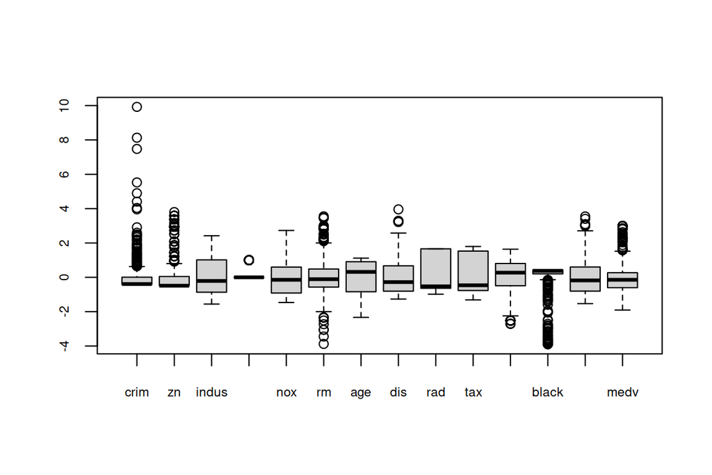

```r
boxplot(as.matrix(data_std), cex.axis = 0.65)
```

```r
data_std <- data_std %>%
  mutate(crime = cut(data_std$crim, breaks =  quantile(data_std$crim), include.lowest = TRUE)) %>%
  dplyr::select(-crim) %>%
  mutate(train = (1:n())%in%sample(x = 1:n(), size = n()*0.8))
levels(data_std$crime) <-  c("low", "med_low", "med_high", "high")
```

## Q5

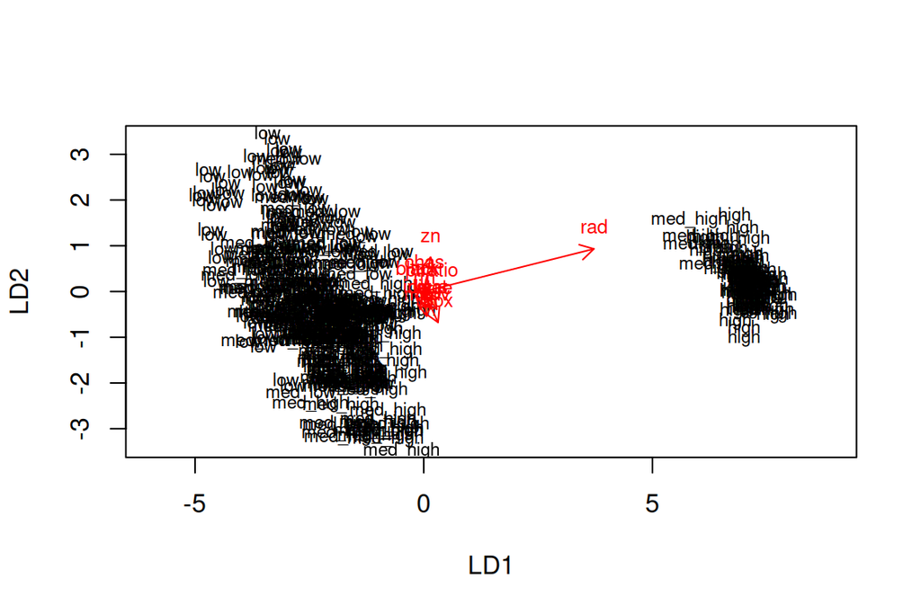

```r
lda_obj <- lda(data_std$crime[data_std$train] ~ ., data = data_std %>% dplyr::select(-crime) %>% filter(train))
plot(lda_obj, dimen = 2)
lda.arrows(lda_obj, myscale = 1)
```

## Q6

```r
lda.pred <- predict(lda_obj, newdata = data_std %>% dplyr::select(-crime) %>% filter(!train))

# cross tabulate the results
table(correct = data_std$crime[!data_std$train], predicted = lda.pred$class)
```

```
##           predicted
## correct    low med_low med_high high
##   low       10      10        4    0
##   med_low    2      17        6    0
##   med_high   1       9       13    2
##   high       0       0        1   27
```

# Chapter 5

```r
library(tidyverse)
library(FactoMineR)
library(corrplot)
set.seed(123) # for sampling columns in Q5
```

## Q1

```r
human <- read_csv("data/human.csv", show_col_types = FALSE)
smr_tbl <- apply(human %>% dplyr::select(-Country), 2, summary)
cor_mat <- cor(human %>% dplyr::select(-Country) %>% as.matrix)
```

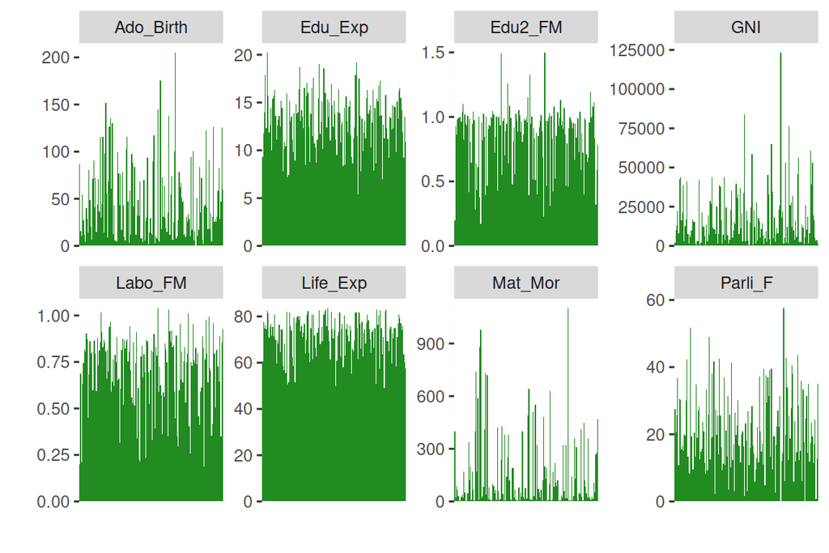

```r
human %>%
  # Switch to "long" format w. 'Country' as identifier
  pivot_longer(-Country, names_to = "Variable", values_to = "Value") %>%
  ggplot(aes(x = Country, y = Value, width=1)) +
  # plot data on bar plot
  geom_bar(stat='identity', fill = "forest green") +
  # 4x2 matrix of barplots
  facet_wrap(~Variable, ncol = 4, nrow = 2, scales = "free_y") +
  # remove the country names, they clutter the output
  theme(axis.text.x = element_blank(),
        axis.ticks.x = element_blank()) +
  # Take out the labels
  xlab("") +
  ylab("")
```

```r
DT::datatable(apply(smr_tbl, 2, round, digits = 2))
```

|  | Edu2_FM | Labo_FM | Edu_Exp | Life_Exp | GNI | Mat_Mor | Ado_Birth | Parli_F |
| --- | --- | --- | --- | --- | --- | --- | --- | --- |
| Min. | 0.17 | 0.19 | 5.4 | 49 | 581 | 1 | 0.6 | 0 |
| 1st Qu. | 0.73 | 0.6 | 11.25 | 66.3 | 4197.5 | 11.5 | 12.65 | 12.4 |
| Median | 0.94 | 0.75 | 13.5 | 74.2 | 12040 | 49 | 33.6 | 19.3 |
| Mean | 0.85 | 0.71 | 13.18 | 71.65 | 17627.9 | 149.08 | 47.16 | 20.91 |
| 3rd Qu. | 1 | 0.85 | 15.2 | 77.25 | 24512 | 190 | 71.95 | 27.95 |
| Max. | 1.5 | 1.04 | 20.2 | 83.5 | 123124 | 1100 | 204.8 | 57.5 |

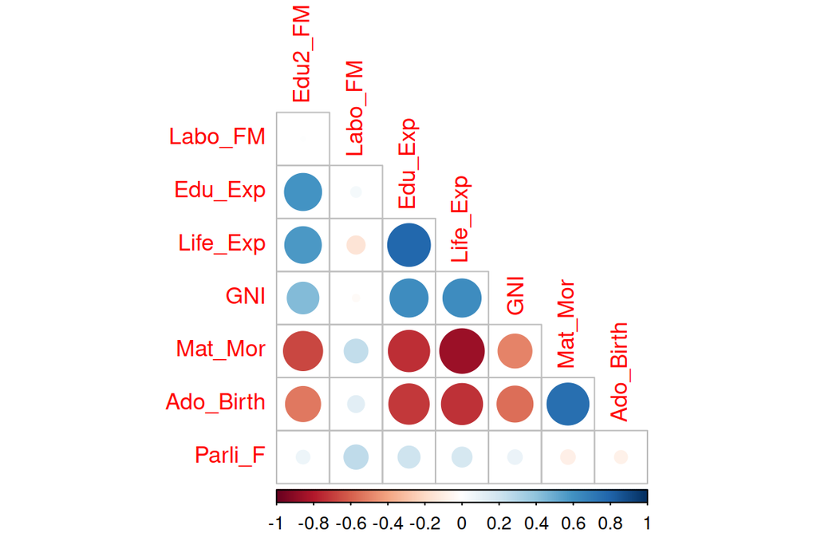

```r
corrplot::corrplot(cor_mat, diag = FALSE, type='lower')
```

## Q2

Below, I give two figures to visualize the PCA. The scree plot shows how much each principal component accounts for the total variance of the variables. We see that the first PC accounts for virtually all of the variance in the data. This can be confirmed from the biplot, in which only one arrow is visible, as the others would have length zero. This PC corresponds to the varible **GNI**, which is of two or three orders of magnitudes larger than the other variables. Therefore, the analysis using the non-standardized variables makes little sense here.

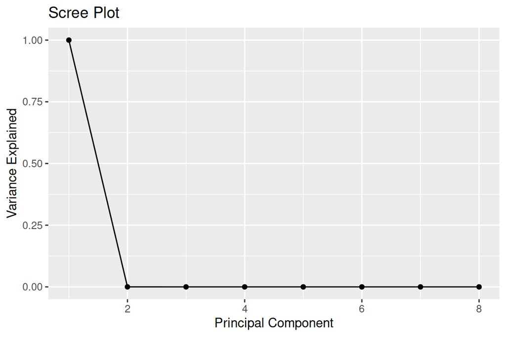

```r
pca_human <- prcomp(human %>% dplyr::select(-Country))
var_explained <- pca_human$sdev^2 / sum(pca_human$sdev^2)
qplot(x = 1:8, y = var_explained) +
  geom_line() +
  xlab("Principal Component") +
  ylab("Variance Explained") +
  ggtitle("Scree Plot") +
  ylim(0, 1)
```

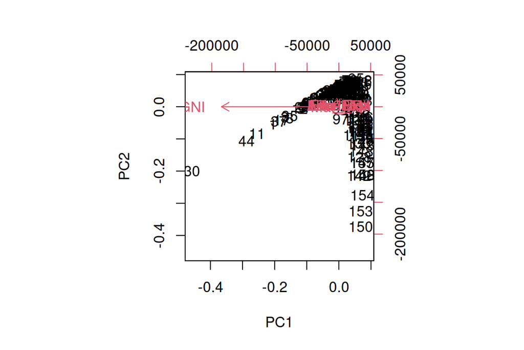

```r
biplot(pca_human, choices = 1:2)
```

## Q3

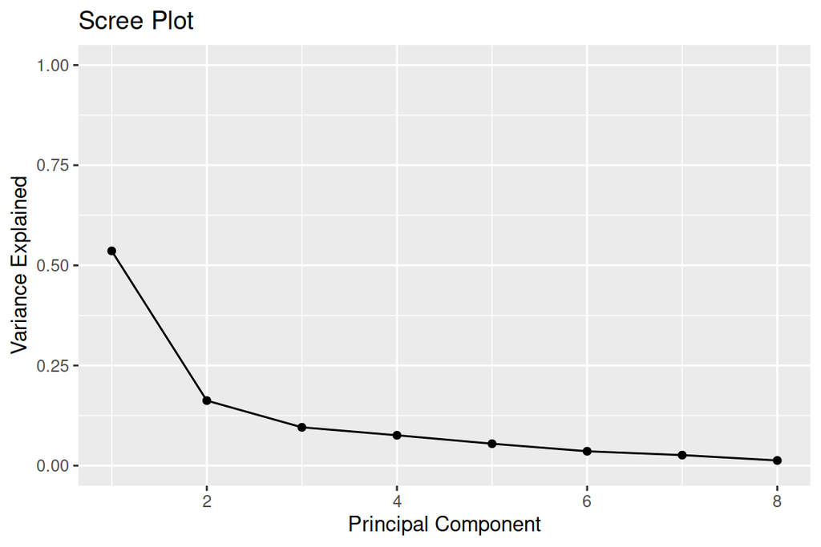

```r
pca_human <- human %>%
  # Select only numeric cols
  dplyr::select(-Country) %>%
  # S'dize data
  mutate_all( ~ (.x-mean(.x))/sd(.x)) %>%
  prcomp()
# calculate the variance explained per variable
var_explained <- pca_human$sdev^2 / sum(pca_human$sdev^2)
# them agains the number of PCs (8)
qplot(1:8, var_explained) +
  geom_line() +
  xlab("Principal Component") +
  ylab("Variance Explained") +
  ggtitle("Scree Plot") +
  ylim(0, 1)
```

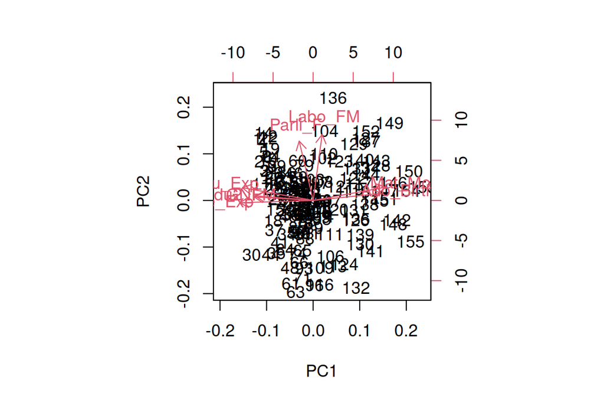

```r
pca_human %>% biplot(choices = 1:2)
```

## Q5

```r
tea <- read.csv("https://raw.githubusercontent.com/KimmoVehkalahti/Helsinki-Open-Data-Science/master/datasets/tea.csv", stringsAsFactors = TRUE)
cls <- tea %>% apply(2, class)
# select 10 random columns
tea_rd <- tea %>% dplyr::select(sample(1:ncol(tea), 10, replace = FALSE))
tea_rd %>% str
```

```
## 'data.frame':    300 obs. of  10 variables:
##  $ feminine: Factor w/ 2 levels "feminine","Not.feminine": 2 2 2 2 2 2 2 1 2 2 ...
##  $ sugar   : Factor w/ 2 levels "No.sugar","sugar": 2 1 1 2 1 1 1 1 1 1 ...
##  $ How     : Factor w/ 4 levels "alone","lemon",..: 1 3 1 1 1 1 1 3 3 1 ...
##  $ evening : Factor w/ 2 levels "evening","Not.evening": 2 2 1 2 1 2 2 1 2 1 ...
##  $ friends : Factor w/ 2 levels "friends","Not.friends": 2 2 1 2 2 2 1 2 2 2 ...
##  $ price   : Factor w/ 6 levels "p_branded","p_cheap",..: 4 6 6 6 6 3 6 6 5 5 ...
##  $ Sport   : Factor w/ 2 levels "Not.sportsman",..: 2 2 2 1 2 2 2 2 2 1 ...
##  $ resto   : Factor w/ 2 levels "Not.resto","resto": 1 1 2 1 1 1 1 1 1 1 ...
##  $ dinner  : Factor w/ 2 levels "dinner","Not.dinner": 2 2 1 1 2 1 2 2 2 2 ...
##  $ sex     : Factor w/ 2 levels "F","M": 2 1 1 2 2 2 2 1 2 2 ...
```

In this data set, I pick randomly ten out of 36 variables for the multiple correspondence analysis. The data are categorical and shown in figure below. The unique values per variable vary from two to six. Some the variables exhibit little variation, e.g. **dinner**, while variable **price** varies considerably more.

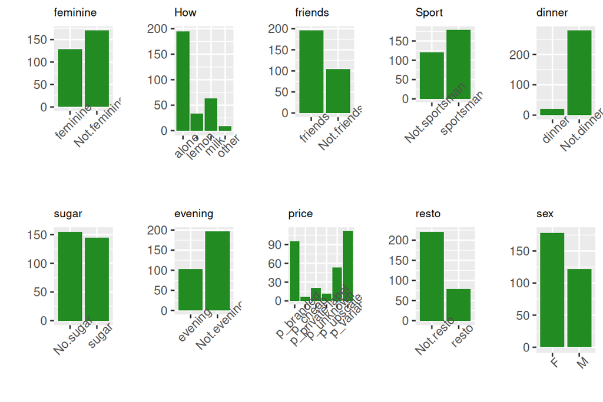

```r
# calculate the number of cases per factor for each variable
get_counts <- apply(tea_rd, 2, table)
plot_list <- list()
for(jj in 1:10){
  # run a loop over the variables s.t. for each var a bar plot is created
  plot_list[[jj]] <- tibble(count = get_counts[[jj]], char = names(get_counts[[jj]])) %>%
    ggplot(aes(x=char, y = count)) +
    geom_bar(stat='identity', fill = "forest green") +
    xlab("") +
    ylab("") +
    ggtitle(names(get_counts)[jj]) +
    theme(axis.text.x = element_text(angle = 45),
          plot.title = element_text(size = 8))

}
# plot variables in a 2-by-5 matrix
gridExtra::marrangeGrob(plot_list, nrow = 2, ncol = 5, top = FALSE)
```

Below I conduct MCA and explore the results verbally and visually. The figure shows that the *principal inertia* is 10.5% for the first dimension and 9.5% for the second. Together, they account for 20% of the variation in the data. Therefore, it can be concluded that the variables are not strongly correlated with each other. This conclusion can be confirmed by looking at the MCA factor map. The factors of each variable are quite *randomly* located along the two dimensions. I would continue on exploring the data to find some more reasonable relationships between the variables.

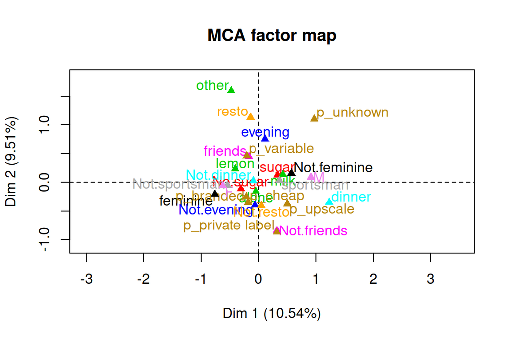

```r
mca <- FactoMineR::MCA(as.matrix(tea_rd), graph = FALSE)
plot(mca, invisible="ind", graph.type = "classic", habillage = "quali")
```

# Chapter 6

```r
library(tidyverse)
library(lme4)
BPRSL <- read_csv("data/BPRSL.csv", show_col_types = FALSE) %>%
  mutate(treatment = factor(treatment)) %>%
  mutate(subject = factor(subject))
RATSL <- read_csv("data/RATSL.csv", show_col_types = FALSE) %>%
  mutate(ID = factor(ID)) %>%
  mutate(Group = factor(Group))
```

## Q1

In this exercise we analyze nutritional data on three groups of rats. The weight of the rats were observed over a time span of 64 days, and the weight was measured every seven days. The development of the weight over the sample span is depicted below. We see that the weights of the rats increase over time, as expected. The first group has the smallest development in weights in absolute terms. The interest is then if there is some differences in the means between the groups. This would indicate differences in the effectiveness of different diets.

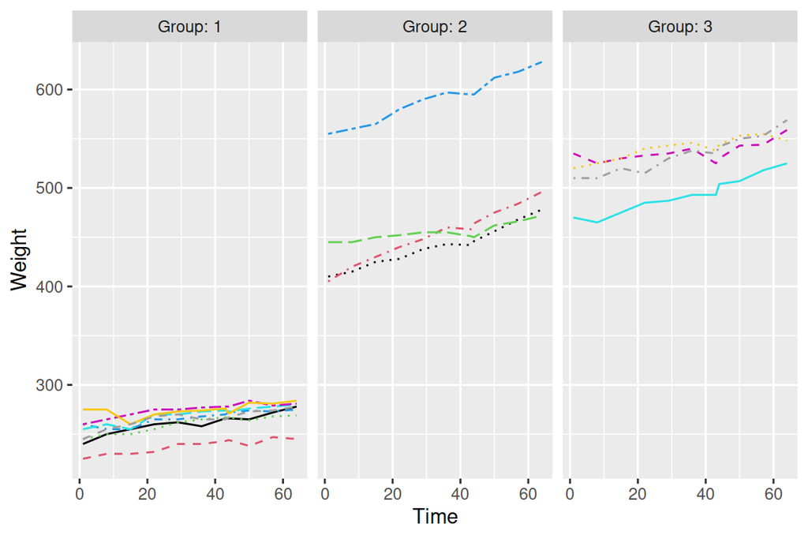

```r
RATSL %>%
  ggplot(aes(x = Time, y = Weight, linetype = ID, color = ID)) +
  geom_line() +
  # fix line types across individuals
  scale_linetype_manual(values = rep(1:length(unique(RATSL$ID)), 3)) +
  # add color to better distinguish between individuals
  scale_color_manual(values = rep(1:length(unique(RATSL$ID)), 3)) +
  # set plots apart across Group
  facet_grid(. ~ Group, labeller = label_both) +
  # remove legend
  theme(legend.position = "none") +
  # set scale y-axis
  scale_y_continuous(limits = c(min(RATSL$Weight), max(RATSL$Weight)))
```

To analyze the question more carefully, the weights are standardized with respect to the measurement time and the resulting values are plotted below. This helps to see if the individuals with higher starting weight tend to have higher weight throughout the sample period. The development of the standardised weight appears approximately the same in nutrition group 1. In groups 2 and 3, there are more variation across the individuals, as is seen from the different slopes of the lines in these two panels.

```r
RATSL <- RATSL %>%
  group_by(Time) %>%
  mutate(stdwght = (Weight - mean(Weight))/sd(Weight)) %>%
  ungroup()
```

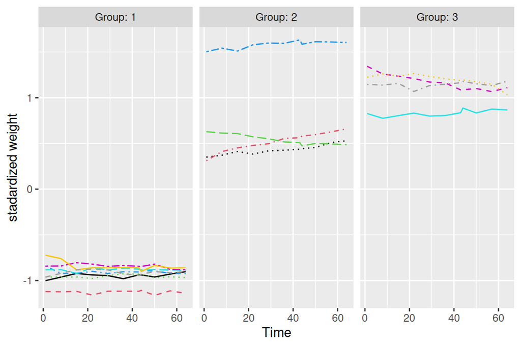

```r
RATSL %>%
  ggplot(aes(x = Time, y = stdwght, linetype = ID, color = ID)) +
  geom_line() +
  # fix line types across individuals
  scale_linetype_manual(values = rep(1:length(unique(RATSL$ID)), 3)) +
  # add color to better distinguish between individuals
  scale_color_manual(values = rep(1:length(unique(RATSL$ID)), 3)) +
  # set plots apart across Group
  facet_grid(. ~ Group, labeller = label_both) +
  # remove legend
  theme(legend.position = "none") +
  # set scale y-axis
  scale_y_continuous(name = "stadardized weight",
                     limits = c(min(RATSL$stdwght), max(RATSL$stdwght)))
```

Next, we analyze the means of the groups. This makes the analysis easier as the objects of interest per time period is reduced to three. The interest is whether the means differ across the time periods. Two thins stand out. First, the mean of group 1 is substantially smaller from those of groups 2 and 3, and does not increase substantially across the sample span. Second, the means of groups 2 and 3 largely overlap. The slopes of the time series are positive and develop similarly. This would indicate that there is no substantial difference in the nutritional effect of these diets.

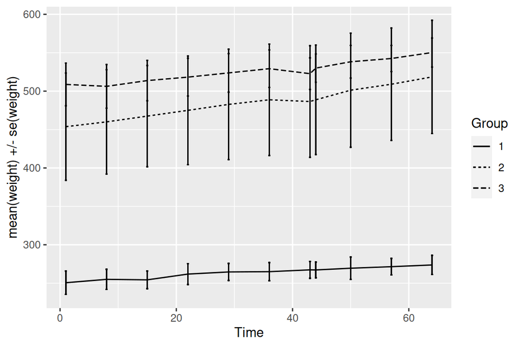

```r
RATSL %>%
  group_by(Group, Time) %>%
  # no need to use summarise() here if data is grouped
  mutate(mean = mean(Weight),
         se = sd(Weight)) %>%
  ungroup() %>%
  ggplot(aes(x = Time, y = mean, linetype = Group)) +
  geom_line() +
  geom_errorbar(aes(ymin=mean-se, ymax=mean+se, linetype="1"), width=0.3) +
  scale_y_continuous(name = "mean(weight) +/- se(weight)")
```

Next, we analyse the question of equal means by box plots. The intuition of last figure is confirmed: group 1 has substantially smaller mean from the rest of the groups. Group two has an outlier value, which is removed from the analysis in the remainder.

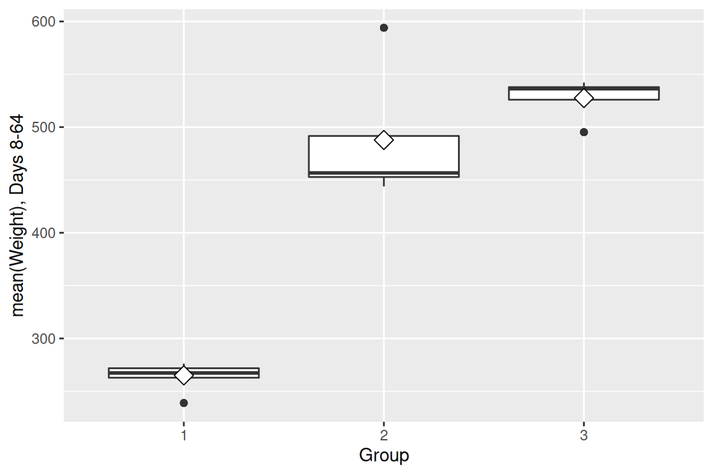

```r
RATSL %>%
  filter(Time > 1) %>%
  group_by(Group, ID) %>%
  mutate(mean=mean(Weight)) %>%
  ungroup() %>%
  ggplot(aes(x = Group, y = mean)) +
  geom_boxplot() +
  stat_summary(fun = "mean", geom = "point", shape=23, size=4, fill = "white") +
  scale_y_continuous(name = "mean(Weight), Days 8-64")
```

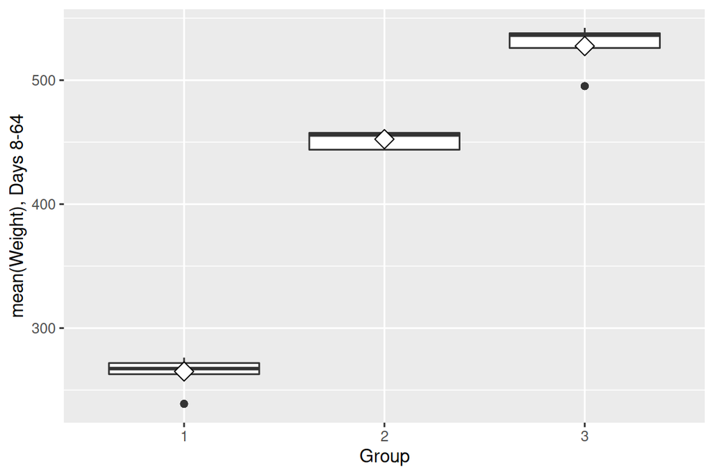

```r
RATSL %>%
  filter(Time > 1) %>%
  group_by(Group, ID) %>%
  mutate(mean=mean(Weight)) %>%
  ungroup() %>%
  # filter out the possible outlier
  filter(mean < max(mean)) %>%
  ggplot(aes(x = Group, y = mean)) +
  geom_boxplot() +
  stat_summary(fun = "mean", geom = "point", shape=23, size=4, fill = "white") +
  scale_y_continuous(name = "mean(Weight), Days 8-64")
```

To test the hypothesis of equal means across the groups, we perform a simple t-test. The null hypothesis of equal means is rejected at the conventional significance levels (p-value <0.01). Therefore, the visual evidence was not supported by the formal hypothesis testing.

```r
anova_data <- RATSL %>%
  filter(Time > 1) %>%
  group_by(Group, ID) %>%
  summarise(mean=mean(Weight)) %>%
  ungroup() %>%
  # filter out the possible outlier
  filter(mean < max(mean)) %>%
  filter(Group%in%c(2,3))

t.test(mean ~ Group, data=anova_data,var.equal=TRUE)
```

```
##
##  Two Sample t-test
##
## data:  mean by Group
## t = -5.632, df = 5, p-value = 0.002446
## alternative hypothesis: true difference in means between group 2 and group 3 is not equal to 0
## 95 percent confidence interval:
##  -109.37769  -40.82231
## sample estimates:
## mean in group 2 mean in group 3
##           452.4           527.5
```

Next, we assess the relationship between the mean weights and their development throughout the sample period using linear regression. The analysis below point towards the conclusion that the mean of the weights has increased across the individuals and time periods as the coefficient for **baseline** is positive and different from zero at the standard confidence levels. This is also backed by the anova-table, which lends support for the conclusion that the coefficients of the linear model are jointly different from zero at 99.9% level.

```r
ols_data <- RATSL %>%
  filter(Time > 1) %>%
  group_by(Group, ID) %>%
  summarise(mean=mean(Weight)) %>%
  ungroup() %>%
  #add baseline group
  mutate(baseline = RATSL %>% filter(Time==1) %>% pull(Weight))

fit <- lm(mean ~ Group + baseline, data = ols_data)
summary(fit)
```

```
##
## Call:
## lm(formula = mean ~ Group + baseline, data = ols_data)
##
## Residuals:
##     Min      1Q  Median      3Q     Max
## -23.905  -4.194   2.190   7.577  14.800
##
## Coefficients:
##             Estimate Std. Error t value Pr(>|t|)
## (Intercept) 33.16375   21.87657   1.516   0.1554
## Group2      34.85753   18.82308   1.852   0.0888 .
## Group3      23.67526   23.25324   1.018   0.3287
## baseline     0.92513    0.08572  10.793 1.56e-07 ***
## ---
## Signif. codes:  0 '***' 0.001 '**' 0.01 '*' 0.05 '.' 0.1 ' ' 1
##
## Residual standard error: 11.68 on 12 degrees of freedom
## Multiple R-squared:  0.9936, Adjusted R-squared:  0.992
## F-statistic: 622.1 on 3 and 12 DF,  p-value: 1.989e-13
```

```r
anova(fit)
```

```
## Analysis of Variance Table
##
## Response: mean
##           Df Sum Sq Mean Sq F value    Pr(>F)
## Group      2 238620  119310  874.89 9.986e-14 ***
## baseline   1  15884   15884  116.48 1.562e-07 ***
## Residuals 12   1636     136
## ---
## Signif. codes:  0 '***' 0.001 '**' 0.01 '*' 0.05 '.' 0.1 ' ' 1
```

## Q2

In this question we analyze data on males answering psychological questionnaire across eight weeks, based on which they were given scores (BPRS). They were given different treatments (coded in the data as treatment:1 or treatment:2). The results of individuals across the sample span is plotted below. The general trend is somewhat downwards. However, the individual differences across the ratings are large.

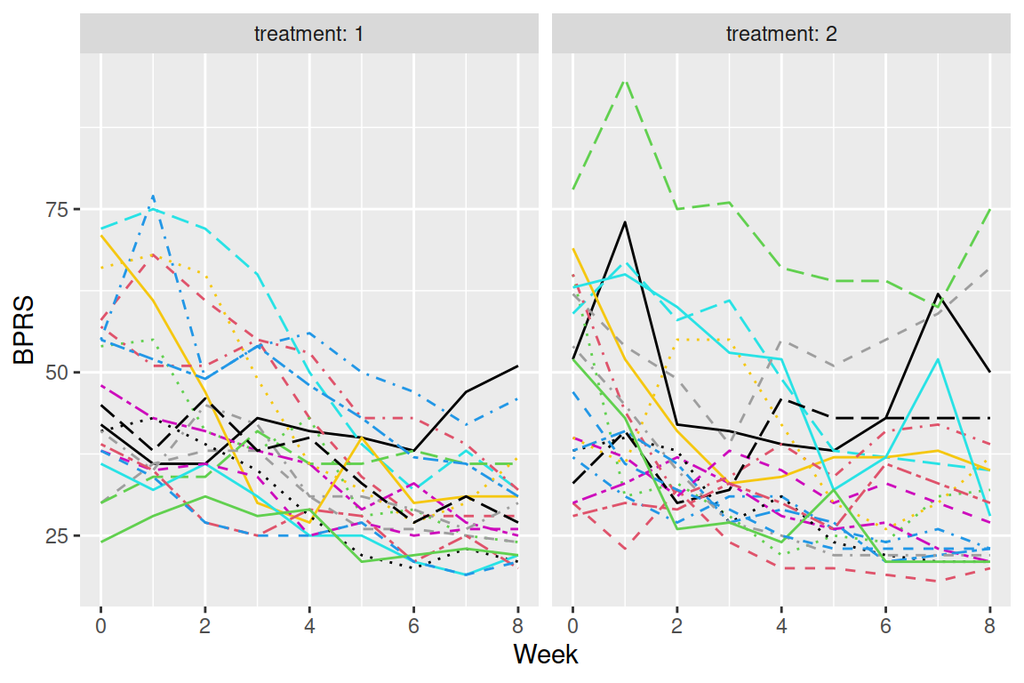

```r
BPRSL %>%
  ggplot(aes(x=Week, y=BPRS, linetype=subject, color=subject)) +
  geom_line() +
  # fix line types across individuals
  scale_linetype_manual(values = rep(1:length(unique(BPRSL$subject)), 2)) +
  # add color to better distinguish between individuals
  scale_color_manual(values = rep(1:length(unique(BPRSL$subject)), 2)) +
  # set plots apart across Group
  facet_grid(. ~ treatment, labeller = label_both) +
  # remove legend
  theme(legend.position = "none")
```

The preliminary analysis on the effect of treatment and the BPRS scores involves a linear regression where the underlying assumption is that the individuals are independent across time. The preliminary results lend support that test scores are decreasing with time, while the differences between groups are non-significant.

```r
lm_obj <- lm(BPRS ~ treatment + Week, data = BPRSL)
summary(lm_obj)
```

```
##
## Call:
## lm(formula = BPRS ~ treatment + Week, data = BPRSL)
##
## Residuals:
##     Min      1Q  Median      3Q     Max
## -22.454  -8.965  -3.196   7.002  50.244
##
## Coefficients:
##             Estimate Std. Error t value Pr(>|t|)
## (Intercept)  46.4539     1.3670  33.982   <2e-16 ***
## treatment2    0.5722     1.3034   0.439    0.661
## Week         -2.2704     0.2524  -8.995   <2e-16 ***
## ---
## Signif. codes:  0 '***' 0.001 '**' 0.01 '*' 0.05 '.' 0.1 ' ' 1
##
## Residual standard error: 12.37 on 357 degrees of freedom
## Multiple R-squared:  0.1851, Adjusted R-squared:  0.1806
## F-statistic: 40.55 on 2 and 357 DF,  p-value: < 2.2e-16
```

Next, we carry out the same analysis but with random intercept for each *subject*. The intercepts are highly variable, and not equal across *subjects* as seen from the results below.

```r
BPRS_ref <- lmer(BPRS ~ Week + treatment + (1 | subject), data = BPRSL, REML = FALSE)
BPRS_ref %>% summary
```

```
## Linear mixed model fit by maximum likelihood  ['lmerMod']
## Formula: BPRS ~ Week + treatment + (1 | subject)
##    Data: BPRSL
##
##      AIC      BIC   logLik deviance df.resid
##   2748.7   2768.1  -1369.4   2738.7      355
##
## Scaled residuals:
##     Min      1Q  Median      3Q     Max
## -3.0481 -0.6749 -0.1361  0.4813  3.4855
##
## Random effects:
##  Groups   Name        Variance Std.Dev.
##  subject  (Intercept)  47.41    6.885
##  Residual             104.21   10.208
## Number of obs: 360, groups:  subject, 20
##
## Fixed effects:
##             Estimate Std. Error t value
## (Intercept)  46.4539     1.9090  24.334
## Week         -2.2704     0.2084 -10.896
## treatment2    0.5722     1.0761   0.532
##
## Correlation of Fixed Effects:
##            (Intr) Week
## Week       -0.437
## treatment2 -0.282  0.000
```

Going forward, we analyse the model by including a random slope for the variable *Week*. This allows even more general interpretation of the predictions. It controls for the different score development profiles between the individual males. The random slope has a considerably smaller variance than that of the random intercept of the individuals. Looking at the differences between the model fit we see that the random slope model is preferred to only random intercept at the 95% confidence level, as seen by the likelihood ratio test (p-value $\approx$ 0.025).

```r
BPRS_ref1 <- lmer(BPRS ~ Week + treatment + (Week | subject), data = BPRSL, REML = FALSE)
summary(BPRS_ref1)
```

```
## Linear mixed model fit by maximum likelihood  ['lmerMod']
## Formula: BPRS ~ Week + treatment + (Week | subject)
##    Data: BPRSL
##
##      AIC      BIC   logLik deviance df.resid
##   2745.4   2772.6  -1365.7   2731.4      353
##
## Scaled residuals:
##     Min      1Q  Median      3Q     Max
## -2.8919 -0.6194 -0.0691  0.5531  3.7976
##
## Random effects:
##  Groups   Name        Variance Std.Dev. Corr
##  subject  (Intercept) 64.8222  8.0512
##           Week         0.9609  0.9802   -0.51
##  Residual             97.4305  9.8707
## Number of obs: 360, groups:  subject, 20
##
## Fixed effects:
##             Estimate Std. Error t value
## (Intercept)  46.4539     2.1052  22.066
## Week         -2.2704     0.2977  -7.626
## treatment2    0.5722     1.0405   0.550
##
## Correlation of Fixed Effects:
##            (Intr) Week
## Week       -0.582
## treatment2 -0.247  0.000
```

```r
anova(BPRS_ref, BPRS_ref1)
```

```
## Data: BPRSL
## Models:
## BPRS_ref: BPRS ~ Week + treatment + (1 | subject)
## BPRS_ref1: BPRS ~ Week + treatment + (Week | subject)
##           npar    AIC    BIC  logLik deviance  Chisq Df Pr(>Chisq)
## BPRS_ref     5 2748.7 2768.1 -1369.4   2738.7
## BPRS_ref1    7 2745.4 2772.6 -1365.7   2731.4 7.2721  2    0.02636 *
## ---
## Signif. codes:  0 '***' 0.001 '**' 0.01 '*' 0.05 '.' 0.1 ' ' 1
```

Finally, we explore if the inclusion of the interaction term capturing the combination of the week and treatment improve the fit. The improvement is modest. The LR test statistic is approx. 3.1 with 1 degrees of freedom yielding a p-value of about 0.075. Therefore, the simpler model is perhaps preferred in this instance.

```r
BPRS_ref2 <- lmer(BPRS ~ Week + treatment + Week*treatment + (Week | subject), data = BPRSL, REML = FALSE)
summary(BPRS_ref2)
```

```
## Linear mixed model fit by maximum likelihood  ['lmerMod']
## Formula: BPRS ~ Week + treatment + Week * treatment + (Week | subject)
##    Data: BPRSL
##
##      AIC      BIC   logLik deviance df.resid
##   2744.3   2775.4  -1364.1   2728.3      352
##
## Scaled residuals:
##     Min      1Q  Median      3Q     Max
## -3.0512 -0.6271 -0.0768  0.5288  3.9260
##
## Random effects:
##  Groups   Name        Variance Std.Dev. Corr
##  subject  (Intercept) 64.9964  8.0620
##           Week         0.9687  0.9842   -0.51
##  Residual             96.4707  9.8220
## Number of obs: 360, groups:  subject, 20
##
## Fixed effects:
##                 Estimate Std. Error t value
## (Intercept)      47.8856     2.2521  21.262
## Week             -2.6283     0.3589  -7.323
## treatment2       -2.2911     1.9090  -1.200
## Week:treatment2   0.7158     0.4010   1.785
##
## Correlation of Fixed Effects:
##             (Intr) Week   trtmn2
## Week        -0.650
## treatment2  -0.424  0.469
## Wek:trtmnt2  0.356 -0.559 -0.840
```

```r
anova(BPRS_ref2, BPRS_ref1)
```

```
## Data: BPRSL
## Models:
## BPRS_ref1: BPRS ~ Week + treatment + (Week | subject)
## BPRS_ref2: BPRS ~ Week + treatment + Week * treatment + (Week | subject)
##           npar    AIC    BIC  logLik deviance  Chisq Df Pr(>Chisq)
## BPRS_ref1    7 2745.4 2772.6 -1365.7   2731.4
## BPRS_ref2    8 2744.3 2775.4 -1364.1   2728.3 3.1712  1    0.07495 .
## ---
## Signif. codes:  0 '***' 0.001 '**' 0.01 '*' 0.05 '.' 0.1 ' ' 1
```